# Predykcja cen mieszkań - Raport nr 3

**Przedmiot:** Metody analizy, przetwarzania i wizualizacji danych  
**Autorzy:** Jakub Nowosad, Łukasz Iwanek, Piotr Białas  
**Data:** 17.05.2026

W trzecim raporcie zajmujemy się **analizą zależności między atrybutami** i **redukcją wymiarowości**. Pracujemy na zbiorze przetworzonym w raporcie nr 2 (`ames_housing_clean.csv`).

```python
import pandas as pd
import numpy as np
import matplotlib.pyplot as plt
import seaborn as sns
from sklearn.decomposition import PCA
from sklearn.cluster import KMeans
from sklearn.metrics import silhouette_score
from sklearn.ensemble import RandomForestRegressor

plt.rcParams['figure.figsize'] = (12, 6)
plt.rcParams['figure.dpi'] = 100
sns.set_theme(style='whitegrid', palette='muted')

df = pd.read_csv('../data/ames_housing_clean.csv')
print(f'Wczytano: {df.shape[0]} wierszy, {df.shape[1]} kolumn')
print(f'Braki: {df.isnull().sum().sum()}')
df.head(3)
```

```
Wczytano: 1454 wierszy, 77 kolumn
Braki: 0
```

|  | MSSubClass | MSZoning | LotFrontage | LotArea | Street | LotShape | LandContour | Utilities | LotConfig | LandSlope | ... | 3SsnPorch | ScreenPorch | PoolArea | MiscVal | MoSold | YrSold | SaleType | SaleCondition | SalePrice | SalePrice_log |
| --- | --- | --- | --- | --- | --- | --- | --- | --- | --- | --- | --- | --- | --- | --- | --- | --- | --- | --- | --- | --- | --- |
| 0 | 0.074469 | 3 | -0.229777 | -0.293439 | 1 | 4 | 3 | 0 | 4 | 3 | ... | -0.116582 | -0.270806 | -0.063797 | -0.086286 | -1.599435 | 0.138123 | 8 | 4 | 208500 | 12.247699 |
| 1 | -0.873253 | 3 | 0.471761 | -0.081054 | 1 | 4 | 3 | 0 | 2 | 3 | ... | -0.116582 | -0.270806 | -0.063797 | -0.086286 | -0.489374 | -0.614051 | 8 | 4 | 181500 | 12.109016 |
| 2 | 0.074469 | 3 | -0.089469 | 0.223673 | 1 | 3 | 3 | 0 | 4 | 3 | ... | -0.116582 | -0.270806 | -0.063797 | -0.086286 | 0.990708 | 0.138123 | 8 | 4 | 223500 | 12.317171 |

3 rows × 77 columns

## 1. Analiza korelacji między atrybutami

Liczymy korelację Pearsona dla wszystkich par kolumn numerycznych. Celem jest:

- znaleźć cechy najsilniej związane ze zmienną docelową (`SalePrice_log`),
- zidentyfikować pary cech o wysokiej wzajemnej korelacji (potencjalna redundancja).

```python
TARGET = 'SalePrice_log'
features = [c for c in df.columns if c not in ['SalePrice', 'SalePrice_log']]

corr_matrix = df[features + [TARGET]].corr(method='pearson')
corr_with_target = corr_matrix[TARGET].drop(TARGET).sort_values(key=abs, ascending=False)

print(f'Liczba cech: {len(features)}')
print(f'\nTop 15 korelacji z {TARGET}:')
print(corr_with_target.head(15).round(3).to_string())
```

```
Liczba cech: 75

Top 15 korelacji z SalePrice_log:
OverallQual     0.823
GrLivArea       0.725
ExterQual       0.686
GarageCars      0.682
KitchenQual     0.673
GarageArea      0.657
TotalBsmtSF     0.645
1stFlrSF        0.618
BsmtQual        0.617
GarageFinish    0.607
FullBath        0.595
YearBuilt       0.590
YearRemodAdd    0.568
FireplaceQu     0.546
TotRmsAbvGrd    0.539
```

### 1.1 Wizualizacja korelacji z ceną

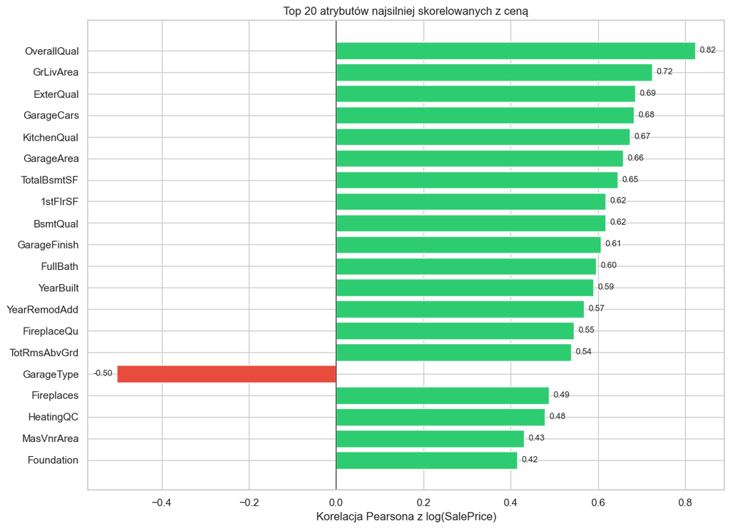

```python
top20 = corr_with_target.head(20)

fig, ax = plt.subplots(figsize=(11, 8))
colors = ['#2ecc71' if v > 0 else '#e74c3c' for v in top20.values]
ax.barh(range(len(top20)), top20.values, color=colors)
ax.set_yticks(range(len(top20)))
ax.set_yticklabels(top20.index)
ax.invert_yaxis()
ax.axvline(0, color='black', linewidth=0.6)
ax.set_xlabel('Korelacja Pearsona z log(SalePrice)')
ax.set_title('Top 20 atrybutów najsilniej skorelowanych z ceną')
for i, v in enumerate(top20.values):
    ax.text(v + (0.01 if v > 0 else -0.01), i, f'{v:.2f}', va='center', ha='left' if v > 0 else 'right', fontsize=9)
plt.tight_layout()
plt.savefig('../reports/figures/12_top_correlations_with_target.png', bbox_inches='tight')
plt.show()
```

### 1.2 Macierz korelacji - top 15 cech

Heatmapa pozwala zobaczyć nie tylko zależność z ceną, ale też wzajemne powiązania między cechami.

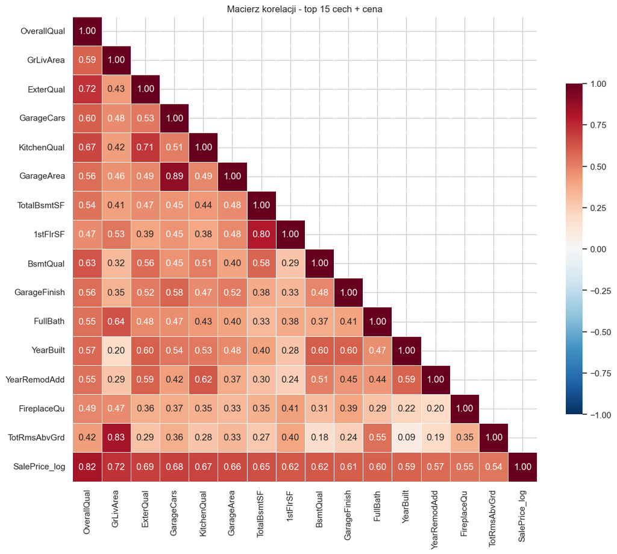

```python
top15_features = corr_with_target.head(15).index.tolist()
corr_top = df[top15_features + [TARGET]].corr()

fig, ax = plt.subplots(figsize=(12, 10))
mask = np.triu(np.ones_like(corr_top, dtype=bool), k=1)
sns.heatmap(corr_top, mask=mask, annot=True, fmt='.2f', cmap='RdBu_r', center=0,
            vmin=-1, vmax=1, square=True, linewidths=0.5, cbar_kws={'shrink': 0.7}, ax=ax)
ax.set_title('Macierz korelacji - top 15 cech + cena')
plt.tight_layout()
plt.savefig('../reports/figures/13_correlation_heatmap_top15.png', bbox_inches='tight')
plt.show()
```

## 2. Identyfikacja cech redundantnych

Szukamy par cech o korelacji |r| > 0.8 - taka redundancja zaburza interpretację modeli liniowych i zwiększa wariancję estymacji.

```python
REDUNDANCY_THRESHOLD = 0.8

feat_corr = df[features].corr().abs()
upper = feat_corr.where(np.triu(np.ones(feat_corr.shape, dtype=bool), k=1))

redundant_pairs = (
    upper.stack()
    .reset_index()
    .rename(columns={'level_0': 'cecha_1', 'level_1': 'cecha_2', 0: 'korelacja'})
    .query('korelacja >= @REDUNDANCY_THRESHOLD')
    .sort_values('korelacja', ascending=False)
    .reset_index(drop=True)
)

print(f'Pary cech z |r| >= {REDUNDANCY_THRESHOLD}: {len(redundant_pairs)}')
redundant_pairs.round(3)
```

```
Pary cech z |r| >= 0.8: 8
```

|  | cecha_1 | cecha_2 | korelacja |
| --- | --- | --- | --- |
| 0 | GarageQual | GarageCond | 0.959 |
| 1 | GarageYrBlt | GarageCond | 0.949 |
| 2 | GarageYrBlt | GarageQual | 0.947 |
| 3 | GarageCars | GarageArea | 0.888 |
| 4 | Fireplaces | FireplaceQu | 0.866 |
| 5 | Exterior1st | Exterior2nd | 0.850 |
| 6 | GrLivArea | TotRmsAbvGrd | 0.830 |
| 7 | TotalBsmtSF | 1stFlrSF | 0.802 |

Dla każdej pary redundantnej wybieramy do usunięcia tę cechę, która **słabiej koreluje z ceną** - zachowujemy ten wariant, który niesie więcej informacji o zmiennej docelowej.

```python
to_drop_redundant = set()
for _, row in redundant_pairs.iterrows():
    c1, c2 = row['cecha_1'], row['cecha_2']
    if c1 in to_drop_redundant or c2 in to_drop_redundant:
        continue
    if abs(corr_with_target[c1]) >= abs(corr_with_target[c2]):
        to_drop_redundant.add(c2)
    else:
        to_drop_redundant.add(c1)

print(f'Cechy do usunięcia (redundantne): {len(to_drop_redundant)}')
for c in sorted(to_drop_redundant):
    print(f'  - {c} (|r| z ceną = {abs(corr_with_target[c]):.3f})')
```

```
Cechy do usunięcia (redundantne): 7
  - 1stFlrSF (|r| z ceną = 0.618)
  - Exterior1st (|r| z ceną = 0.295)
  - Fireplaces (|r| z ceną = 0.488)
  - GarageArea (|r| z ceną = 0.657)
  - GarageCond (|r| z ceną = 0.357)
  - GarageYrBlt (|r| z ceną = 0.349)
  - TotRmsAbvGrd (|r| z ceną = 0.539)
```

## 3. Identyfikacja cech mało informacyjnych

Kryteria:

- bardzo niska wariancja (cecha prawie stała),
- bardzo słaba korelacja z ceną (|r| < 0.05).

Dane są zestandaryzowane (var ≈ 1) tylko dla części ciągłych, więc dodatkowo sprawdzamy *udział dominującej wartości* - cecha, w której >95% rekordów ma tę samą wartość, jest mało informacyjna.

```python
DOMINANT_THRESHOLD = 0.95
LOW_CORR_THRESHOLD = 0.05

low_info = []
for col in features:
    dominant_share = df[col].value_counts(normalize=True).iloc[0]
    corr_abs = abs(corr_with_target[col])
    reasons = []
    if dominant_share >= DOMINANT_THRESHOLD:
        reasons.append(f'jedna wartość w {dominant_share:.1%}')
    if corr_abs < LOW_CORR_THRESHOLD:
        reasons.append(f'|r| z ceną = {corr_abs:.3f}')
    if reasons:
        low_info.append({'cecha': col, 'dominacja': dominant_share, 'corr_z_cena': corr_with_target[col], 'powod': '; '.join(reasons)})

low_info_df = pd.DataFrame(low_info).sort_values('dominacja', ascending=False)
print(f'Cechy mało informacyjne: {len(low_info_df)}')
low_info_df.round(3)
```

```
Cechy mało informacyjne: 19
```

|  | cecha | dominacja | corr_z_cena | powod |
| --- | --- | --- | --- | --- |
| 2 | Utilities | 0.999 | -0.013 | jedna wartość w 99.9%; \|r\| z ceną = 0.013 |
| 0 | Street | 0.997 | 0.072 | jedna wartość w 99.7% |
| 15 | PoolArea | 0.996 | 0.075 | jedna wartość w 99.6% |
| 4 | Condition2 | 0.990 | 0.000 | jedna wartość w 99.0%; \|r\| z ceną = 0.000 |
| 14 | 3SsnPorch | 0.983 | 0.056 | jedna wartość w 98.3% |
| 6 | RoofMatl | 0.983 | 0.108 | jedna wartość w 98.3% |
| 11 | LowQualFinSF | 0.982 | -0.038 | jedna wartość w 98.2%; \|r\| z ceną = 0.038 |
| 10 | Heating | 0.979 | -0.145 | jedna wartość w 97.9% |
| 16 | MiscVal | 0.966 | -0.021 | jedna wartość w 96.6%; \|r\| z ceną = 0.021 |
| 13 | KitchenAbvGr | 0.953 | -0.147 | jedna wartość w 95.3% |
| 3 | LandSlope | 0.949 | -0.013 | \|r\| z ceną = 0.013 |
| 12 | BsmtHalfBath | 0.944 | -0.008 | \|r\| z ceną = 0.008 |
| 1 | LandContour | 0.902 | 0.038 | \|r\| z ceną = 0.038 |
| 9 | BsmtFinSF2 | 0.887 | -0.002 | \|r\| z ceną = 0.002 |
| 18 | SaleType | 0.869 | -0.038 | \|r\| z ceną = 0.038 |
| 8 | BsmtFinType2 | 0.861 | 0.010 | \|r\| z ceną = 0.010 |
| 7 | MasVnrType | 0.598 | -0.016 | \|r\| z ceną = 0.016 |
| 5 | OverallCond | 0.562 | -0.037 | \|r\| z ceną = 0.037 |
| 17 | YrSold | 0.232 | -0.037 | \|r\| z ceną = 0.037 |

```python
# Łączymy redundantne + mało informacyjne (cechy ze słabą korelacją zostawiamy ostrożnie, usuwamy tylko quasi-stałe)
quasi_constant = set(low_info_df.loc[low_info_df['dominacja'] >= DOMINANT_THRESHOLD, 'cecha'])
to_drop_all = to_drop_redundant | quasi_constant

selected_features = [c for c in features if c not in to_drop_all]
print(f'Przed selekcją: {len(features)} cech')
print(f'Usunięte (redundantne): {len(to_drop_redundant)}')
print(f'Usunięte (quasi-stałe): {len(quasi_constant - to_drop_redundant)}')
print(f'Po selekcji: {len(selected_features)} cech')
```

```
Przed selekcją: 75 cech
Usunięte (redundantne): 7
Usunięte (quasi-stałe): 10
Po selekcji: 58 cech
```

## 4. Wybór najważniejszych cech do dalszej analizy

Łączymy dwa rankingi:

- **|r| z ceną** - prosta miara liniowej zależności,
- **feature importance z Random Forest** - łapie też zależności nieliniowe i interakcje.

```python
X = df[selected_features]
y = df[TARGET]

rf = RandomForestRegressor(n_estimators=200, random_state=42, n_jobs=-1)
rf.fit(X, y)

importance = pd.Series(rf.feature_importances_, index=selected_features).sort_values(ascending=False)
corr_abs_sel = corr_with_target.loc[selected_features].abs().sort_values(ascending=False)

ranking = pd.DataFrame({
    'rank_corr': corr_abs_sel.rank(ascending=False),
    'rank_rf': importance.rank(ascending=False),
    'corr_abs': corr_abs_sel,
    'rf_importance': importance,
})
ranking['rank_sredni'] = (ranking['rank_corr'] + ranking['rank_rf']) / 2
ranking = ranking.sort_values('rank_sredni')

top_features = ranking.head(20).index.tolist()
print('Top 20 cech (uśredniony ranking korelacja + Random Forest):')
ranking.head(20).round(3)
```

```
Top 20 cech (uśredniony ranking korelacja + Random Forest):
```

|  | rank_corr | rank_rf | corr_abs | rf_importance | rank_sredni |
| --- | --- | --- | --- | --- | --- |
| OverallQual | 1.0 | 1.0 | 0.823 | 0.565 | 1.0 |
| GrLivArea | 2.0 | 2.0 | 0.725 | 0.117 | 2.0 |
| GarageCars | 4.0 | 4.0 | 0.682 | 0.045 | 4.0 |
| TotalBsmtSF | 6.0 | 3.0 | 0.645 | 0.059 | 4.5 |
| YearBuilt | 10.0 | 6.0 | 0.590 | 0.017 | 8.0 |
| GarageType | 13.0 | 8.0 | 0.502 | 0.013 | 10.5 |
| BsmtFinSF1 | 17.0 | 5.0 | 0.389 | 0.020 | 11.0 |
| GarageFinish | 8.0 | 14.0 | 0.607 | 0.007 | 11.0 |
| YearRemodAdd | 11.0 | 11.0 | 0.568 | 0.009 | 11.0 |
| FireplaceQu | 12.0 | 13.0 | 0.546 | 0.008 | 12.5 |
| LotArea | 19.0 | 7.0 | 0.364 | 0.015 | 13.0 |
| BsmtQual | 7.0 | 19.0 | 0.617 | 0.004 | 13.0 |
| KitchenQual | 5.0 | 25.0 | 0.673 | 0.003 | 15.0 |
| CentralAir | 22.0 | 9.0 | 0.352 | 0.012 | 15.5 |
| LotFrontage | 18.0 | 15.0 | 0.366 | 0.007 | 16.5 |
| ExterQual | 3.0 | 33.0 | 0.686 | 0.002 | 18.0 |
| MasVnrArea | 15.0 | 26.0 | 0.431 | 0.003 | 20.5 |
| FullBath | 9.0 | 34.0 | 0.595 | 0.002 | 21.5 |
| 2ndFlrSF | 26.0 | 17.0 | 0.323 | 0.005 | 21.5 |
| BsmtFinType1 | 24.0 | 21.0 | 0.334 | 0.004 | 22.5 |

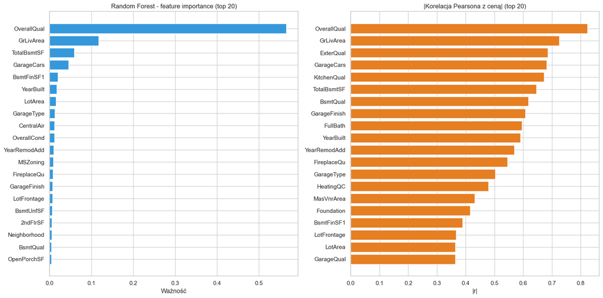

```python
fig, axes = plt.subplots(1, 2, figsize=(16, 8))

top20_rf = importance.head(20)
axes[0].barh(range(len(top20_rf)), top20_rf.values, color='#3498db')
axes[0].set_yticks(range(len(top20_rf)))
axes[0].set_yticklabels(top20_rf.index)
axes[0].invert_yaxis()
axes[0].set_title('Random Forest - feature importance (top 20)')
axes[0].set_xlabel('Ważność')

top20_corr = corr_abs_sel.head(20)
axes[1].barh(range(len(top20_corr)), top20_corr.values, color='#e67e22')
axes[1].set_yticks(range(len(top20_corr)))
axes[1].set_yticklabels(top20_corr.index)
axes[1].invert_yaxis()
axes[1].set_title('|Korelacja Pearsona z ceną| (top 20)')
axes[1].set_xlabel('|r|')

plt.tight_layout()
plt.savefig('../reports/figures/14_feature_importance_ranking.png', bbox_inches='tight')
plt.show()
```

## 5. Redukcja wymiarowości - PCA

Stosujemy PCA na pełnym zestawie cech po selekcji (`selected_features`), żeby zobaczyć:

- ile komponentów wystarcza do zachowania 90-95% wariancji,
- jak rozkładają się rekordy w przestrzeni dwóch pierwszych komponentów,
- które oryginalne cechy najmocniej wchodzą w skład pierwszych komponentów.

```python
X_sel = df[selected_features].values

pca_full = PCA()
pca_full.fit(X_sel)

explained = pca_full.explained_variance_ratio_
cumulative = explained.cumsum()

n_for_90 = int(np.searchsorted(cumulative, 0.90) + 1)
n_for_95 = int(np.searchsorted(cumulative, 0.95) + 1)

print(f'Komponenty na 90% wariancji: {n_for_90}')
print(f'Komponenty na 95% wariancji: {n_for_95}')
print(f'Wariancja PC1: {explained[0]:.1%}')
print(f'Wariancja PC2: {explained[1]:.1%}')
print(f'Wariancja PC1+PC2: {cumulative[1]:.1%}')
```

```
Komponenty na 90% wariancji: 22
Komponenty na 95% wariancji: 31
Wariancja PC1: 30.4%
Wariancja PC2: 22.3%
Wariancja PC1+PC2: 52.7%
```

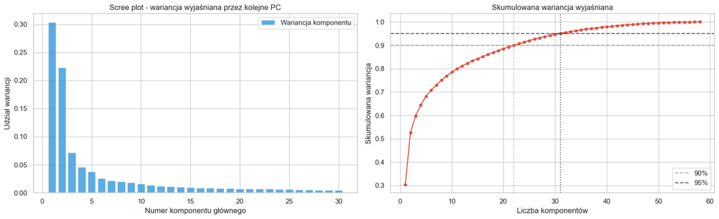

```python
fig, axes = plt.subplots(1, 2, figsize=(16, 5))

k = min(30, len(explained))
axes[0].bar(range(1, k + 1), explained[:k], color='#3498db', alpha=0.8, label='Wariancja komponentu')
axes[0].set_xlabel('Numer komponentu głównego')
axes[0].set_ylabel('Udział wariancji')
axes[0].set_title('Scree plot - wariancja wyjaśniana przez kolejne PC')
axes[0].legend(loc='upper right')

axes[1].plot(range(1, len(cumulative) + 1), cumulative, marker='o', color='#e74c3c', markersize=4)
axes[1].axhline(0.9, color='gray', linestyle='--', alpha=0.6, label='90%')
axes[1].axhline(0.95, color='black', linestyle='--', alpha=0.6, label='95%')
axes[1].axvline(n_for_90, color='gray', linestyle=':', alpha=0.6)
axes[1].axvline(n_for_95, color='black', linestyle=':', alpha=0.6)
axes[1].set_xlabel('Liczba komponentów')
axes[1].set_ylabel('Skumulowana wariancja')
axes[1].set_title('Skumulowana wariancja wyjaśniana')
axes[1].legend()

plt.tight_layout()
plt.savefig('../reports/figures/15_pca_scree.png', bbox_inches='tight')
plt.show()
```

### 5.1 Projekcja danych na PC1-PC2

Kolor punktów to log(SalePrice) - sprawdzamy, czy w przestrzeni PC1-PC2 widać układ cenowy.

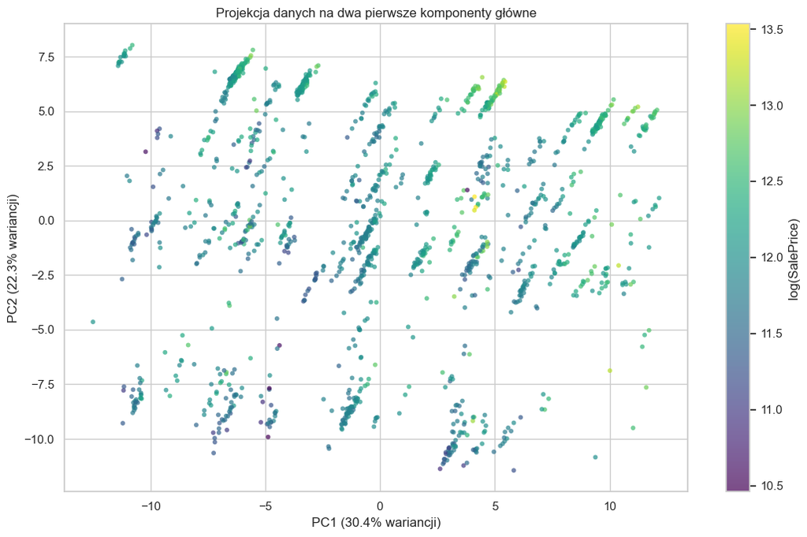

```python
pca2 = PCA(n_components=2)
X_pca = pca2.fit_transform(X_sel)

fig, ax = plt.subplots(figsize=(11, 7))
sc = ax.scatter(X_pca[:, 0], X_pca[:, 1], c=y, cmap='viridis', s=18, alpha=0.7, edgecolor='none')
cb = plt.colorbar(sc, ax=ax)
cb.set_label('log(SalePrice)')
ax.set_xlabel(f'PC1 ({pca2.explained_variance_ratio_[0]:.1%} wariancji)')
ax.set_ylabel(f'PC2 ({pca2.explained_variance_ratio_[1]:.1%} wariancji)')
ax.set_title('Projekcja danych na dwa pierwsze komponenty główne')
plt.tight_layout()
plt.savefig('../reports/figures/16_pca_scatter_price.png', bbox_inches='tight')
plt.show()
```

### 5.2 Co reprezentują pierwsze komponenty?

Loadingi pokazują, które oryginalne cechy najmocniej budują dany komponent.

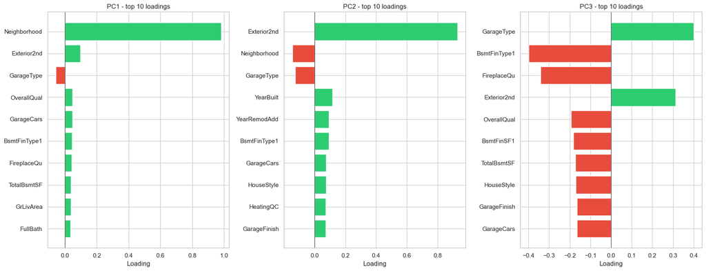

```
Top cechy budujące PC1:
Neighborhood    0.980
Exterior2nd     0.098
GarageType      0.056
OverallQual     0.048
GarageCars      0.046
```

```python
loadings = pd.DataFrame(
    pca_full.components_[:3].T,
    index=selected_features,
    columns=['PC1', 'PC2', 'PC3'],
)

fig, axes = plt.subplots(1, 3, figsize=(18, 7))
for i, pc in enumerate(['PC1', 'PC2', 'PC3']):
    top = loadings[pc].abs().sort_values(ascending=False).head(10).index
    vals = loadings.loc[top, pc]
    colors = ['#2ecc71' if v > 0 else '#e74c3c' for v in vals]
    axes[i].barh(range(len(vals)), vals.values, color=colors)
    axes[i].set_yticks(range(len(vals)))
    axes[i].set_yticklabels(vals.index)
    axes[i].invert_yaxis()
    axes[i].axvline(0, color='black', linewidth=0.6)
    axes[i].set_title(f'{pc} - top 10 loadings')
    axes[i].set_xlabel('Loading')

plt.tight_layout()
plt.savefig('../reports/figures/17_pca_loadings.png', bbox_inches='tight')
plt.show()

print('Top cechy budujące PC1:')
print(loadings['PC1'].abs().sort_values(ascending=False).head(5).round(3).to_string())
```

## 6. Grupowanie K-Means na komponentach głównych

Pomocniczo - sprawdzamy czy domy dzielą się na naturalne segmenty. Używamy pierwszych komponentów obejmujących 90% wariancji jako wejścia do K-Means. Optymalną liczbę klastrów wybieramy przez współczynnik silhouette.

```
Najlepsze k wg silhouette: 3 (score = 0.226)
```

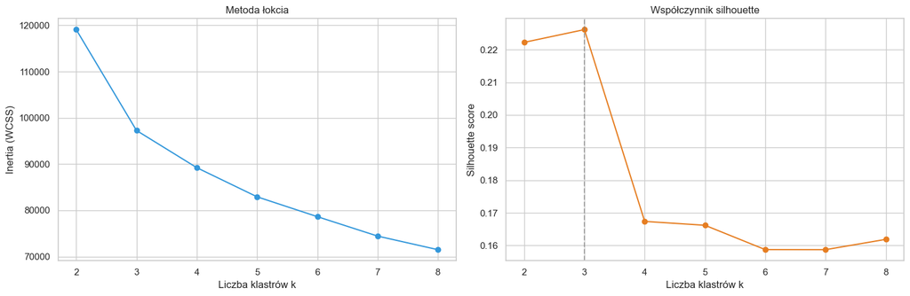

```python
pca_kmeans = PCA(n_components=n_for_90)
X_for_kmeans = pca_kmeans.fit_transform(X_sel)

k_range = range(2, 9)
inertias, silhouettes = [], []
for k in k_range:
    km = KMeans(n_clusters=k, n_init=10, random_state=42)
    labels = km.fit_predict(X_for_kmeans)
    inertias.append(km.inertia_)
    silhouettes.append(silhouette_score(X_for_kmeans, labels, sample_size=1000, random_state=42))

best_k = list(k_range)[int(np.argmax(silhouettes))]
print(f'Najlepsze k wg silhouette: {best_k} (score = {max(silhouettes):.3f})')

fig, axes = plt.subplots(1, 2, figsize=(15, 5))
axes[0].plot(list(k_range), inertias, marker='o', color='#3498db')
axes[0].set_xlabel('Liczba klastrów k')
axes[0].set_ylabel('Inertia (WCSS)')
axes[0].set_title('Metoda łokcia')
axes[1].plot(list(k_range), silhouettes, marker='o', color='#e67e22')
axes[1].axvline(best_k, color='gray', linestyle='--', alpha=0.6)
axes[1].set_xlabel('Liczba klastrów k')
axes[1].set_ylabel('Silhouette score')
axes[1].set_title('Współczynnik silhouette')
plt.tight_layout()
plt.savefig('../reports/figures/18_kmeans_selection.png', bbox_inches='tight')
plt.show()
```

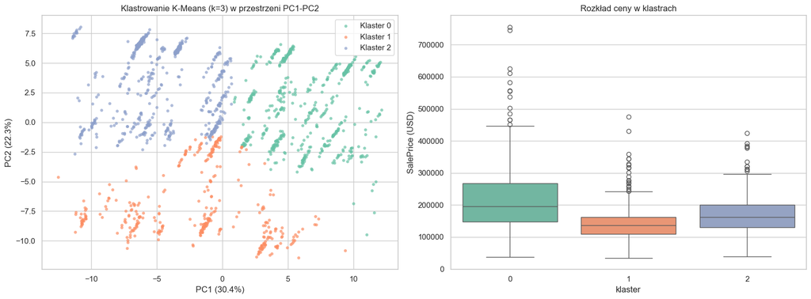

```
Statystyki klastrów:
         liczba  srednia_cena  mediana_cena  sr_powierzchnia  sr_jakosc
klaster
0           525      219128.1      196000.0              0.3        0.5
1           360      143712.4      137000.0             -0.2       -0.5
2           569      168433.2      162900.0             -0.2       -0.1
```

```python
kmeans = KMeans(n_clusters=best_k, n_init=10, random_state=42)
cluster_labels = kmeans.fit_predict(X_for_kmeans)
df_clusters = df.copy()
df_clusters['klaster'] = cluster_labels

fig, axes = plt.subplots(1, 2, figsize=(16, 6))

palette = sns.color_palette('Set2', n_colors=best_k)
for cl in range(best_k):
    mask = cluster_labels == cl
    axes[0].scatter(X_pca[mask, 0], X_pca[mask, 1], s=18, alpha=0.7, color=palette[cl], label=f'Klaster {cl}', edgecolor='none')
axes[0].set_xlabel(f'PC1 ({pca2.explained_variance_ratio_[0]:.1%})')
axes[0].set_ylabel(f'PC2 ({pca2.explained_variance_ratio_[1]:.1%})')
axes[0].set_title(f'Klastrowanie K-Means (k={best_k}) w przestrzeni PC1-PC2')
axes[0].legend()

sns.boxplot(data=df_clusters, x='klaster', y='SalePrice', ax=axes[1], palette=palette)
axes[1].set_title('Rozkład ceny w klastrach')
axes[1].set_ylabel('SalePrice (USD)')

plt.tight_layout()
plt.savefig('../reports/figures/19_kmeans_clusters.png', bbox_inches='tight')
plt.show()

print('Statystyki klastrów:')
print(df_clusters.groupby('klaster').agg(
    liczba=('SalePrice', 'size'),
    srednia_cena=('SalePrice', 'mean'),
    mediana_cena=('SalePrice', 'median'),
    sr_powierzchnia=('GrLivArea', 'mean'),
    sr_jakosc=('OverallQual', 'mean'),
).round(1).to_string())
```

## 7. Interpretacja wyników

### Co pokazała analiza korelacji?

Cena (log) najsilniej koreluje z **OverallQual** (≈0.82), **GrLivArea** (≈0.73), **GarageCars** (≈0.68) i **TotalBsmtSF** (≈0.65). To te same atrybuty, które pojawiły się w raporcie nr 1, ale po preprocessingu (log-transformacja, kodowanie) korelacje są wyraźnie wyższe i bardziej liniowe.

### Cechy mało informacyjne

Część cech (np. `Street`, `Utilities`, `Condition2`, `RoofMatl`) ma ponad 95% rekordów o tej samej wartości - są praktycznie stałe i nic nie wnoszą do modeli.

### Ograniczenia

- PCA na danych ze zmiennymi zakodowanymi label-encoderem zachowuje się gorzej niż na czysto numerycznych - kategorie po zakodowaniu mają nominalny porządek, który PCA traktuje jak ilościowy.
- Korelacja Pearsona łapie tylko zależności liniowe; dla zmiennych ordinalnych warto byłoby porównać ze Spearmanem.
- Random Forest jako miara ważności faworyzuje cechy z dużą liczbą poziomów.

## 8. Screeny z narzędzia (PyCharm)

**Struktura projektu:**

[figure not shown]

**Notebook w edytorze:**

[figure not shown]

**Podgląd wykresu:**

[figure not shown]

## 9. Podsumowanie

Zredukowany zestaw cech i wnioski z PCA będą podstawą do budowy modeli regresyjnych w finalnej części projektu (modele liniowe, drzewa, ensembling).